# Homework 19072

## Question 1

The natural logarithm and exponential functions are inverses of each other, so that mathematically log(exp x) = exp(logx) = x. Show by example that this property does not hold exactly in computer arithmetic. Does the identity hold with near equality? (See all.equal.)

## Question 2

Write a function to solve the equation
$$\begin{aligned} \frac{2 \Gamma\left(\frac{k}{2}\right)}{\sqrt{\pi(k-1) \Gamma\left(\frac{k-1}{2}\right)}} \int_{0}^{c_{k-1}}\left(1+\frac{u^{2}}{k-1}\right)^{-k / 2} d u & \\=& \frac{2 \Gamma\left(\frac{k+1}{2}\right)}{\sqrt{\pi k} \Gamma\left(\frac{k}{2}\right)} \int_{0}^{c_{k}}\left(1+\frac{u^{2}}{k}\right)^{-(k+1) / 2} d u \end{aligned}$$
for $a$,where
$$c_{k}=\sqrt{\frac{a^{2} k}{k+1-a^{2}}}$$
Compare the solutions with the points $A(k)$ in Exercise 11.4.

## Question 3

A-B-O blood type problem Let the three alleles be A, B and O with allele frequencies p, q and r. The 6 genotype frequencies under HWE and complete counts are as follows.

Genotype AA BB OO AO BO AB Sum

Frequency p^2 q^2 r^2 2pr 2qr 2pq 1

Count nAA nBB nOO nAO nBO nAB n

Observed data: nA· = nAA + nAO = 28 (A-type), nB· = nBB + nBO = 24 (B-type), nOO = 41 (O-type),nAB = 70 (AB-type).

1. Use EM algorithm to solve MLE of p and q (consider missing data nAA and nBB).
2. Show that the log-maximum likelihood values in M-steps are increasing via line plot.

## answer 1

```r
x<-seq(2,16,2)
a<-log(exp(x))
b<-exp(log(x))
a==b
```

```
## [1]  TRUE  TRUE  TRUE FALSE FALSE  TRUE FALSE FALSE
```

```r
a==x
```

```
## [1] TRUE TRUE TRUE TRUE TRUE TRUE TRUE TRUE
```

```r
b==x
```

```
## [1]  TRUE  TRUE  TRUE FALSE FALSE  TRUE FALSE FALSE
```

```r
isTRUE(all.equal(a,b))
```

```
## [1] TRUE
```

From the result above,log(exp(x)) = exp(log(x)) does not hold exactly in computer arithmetic when x euqls 8,10,14,16,but the identity hold with near equality.

## answer 2

```r
k<-c(5:25,100) ##The root of equation hasn't been solved when k equals 4,so the loop starts when k equals 5
root<-numeric(length(k))
for (i in 1:length(k))
{
  coef<-function(k)
  {
   return(gamma((k+1)/2)/(gamma(k/2)*sqrt(k*pi)))
    ## the coefficient of integral
  }
 f<-function(a)
{
(coef(k[i])*(integrate(function(x)(1+(x^2)/k[i])^(-(1+k[i])/2),lower=sqrt((a^2)*k[i]/(k[i]+1-a^2)),upper=Inf)$value)- coef(k[i]-1)*(integrate(function(x) (1+(x^2)/(k[i]-1))^(-k[i]/2),lower=sqrt((a^2)*(k[i]-1)/(k[i]-a^2)),upper=Inf)$value))
}
root[i]<-uniroot(f,lower =0.01,upper = 1+sqrt(k[i])/2)$root
}
data.frame(k,root)
```

```
##      k     root
## 1    5 1.533576
## 2    6 1.562721
## 3    7 1.584427
## 4    8 1.601166
## 5    9 1.614524
## 6   10 1.625385
## 7   11 1.634415
## 8   12 1.642027
## 9   13 1.648536
## 10  14 1.654175
## 11  15 1.659097
## 12  16 1.663408
## 13  17 1.667301
## 14  18 1.670724
## 15  19 1.673819
## 16  20 1.676589
## 17  21 1.679154
## 18  22 1.681470
## 19  23 1.683610
## 20  24 1.685548
## 21  25 1.687347
## 22 100 1.720610
```

```r
k<-c(4:25,100)
## ##The root of equation hasn't been solved when k equals 500 and 1000,so the loop starts from k equals 4 to k equals 100.
root<-numeric(length(k))
for (i in 1:length(k))
{
  coef<-function(k)
  {
   return(gamma((k+1)/2)/(gamma(k/2)*sqrt(k*pi)))
    ## the coefficient of integral
  }
 f<-function(a)
{
(coef(k[i])*(integrate(function(x)(1+(x^2)/k[i])^(-(1+k[i])/2),lower=0,upper=sqrt((a^2)*k[i]/(k[i]+1-a^2)))$value)- coef(k[i]-1)*(integrate(function(x) (1+(x^2)/(k[i]-1))^(-k[i]/2),lower=0,upper=sqrt((a^2)*(k[i]-1)/(k[i]-a^2)))$value))
}
root[i]<-uniroot(f,lower =0.01,upper = 1+sqrt(k[i])/2)$root
}
data.frame(k,root)
```

```
##      k     root
## 1    4 1.492103
## 2    5 1.533576
## 3    6 1.562721
## 4    7 1.584427
## 5    8 1.601166
## 6    9 1.614524
## 7   10 1.625385
## 8   11 1.634415
## 9   12 1.642027
## 10  13 1.648536
## 11  14 1.654175
## 12  15 1.659097
## 13  16 1.663408
## 14  17 1.667301
## 15  18 1.670724
## 16  19 1.673819
## 17  20 1.676589
## 18  21 1.679154
## 19  22 1.681470
## 20  23 1.683610
## 21  24 1.685548
## 22  25 1.687347
## 23 100 1.720610
```

By comparing the two tables, we can findthat when the root can be solved, the value of the root is the same when the k is given.

## answer 3

```r
p <- q <- r <- numeric(1000)
nA. <- 28; nB. <- 24; nOO <- 41; nAB <- 70
p[1] <- 0.09; q[1] <- 0.23;r[1] <- (1- p[1]- q[1])
threshold <- 2e-6


f <- function(a,b) {
  return((nB.*b/(2-b-2*a)+nB.+nAB)/(nA.*a/(2-a-2*b)+nA.+nAB))
}
g <- function(a,b) {
 return(((1-a/(2-a-2*b))*nA.+(1-b/(2-b-2*a))*nB.+2*nOO)/((nB.*b/(2-b-2*a)+
                          nB.+nAB)))
}

for (i in 2:1000)
   {
   p[i] <- 1/(1+f(p[i-1],q[i-1])*(1+g(p[i-1],q[i-1])))
   ## the maximum likelihood estimation of p
   q[i] <- f(p[i-1],q[i-1])/(1+f(p[i-1],q[i-1])*(1+g(p[i-1],q[i-1])))
   ## the maximum likelihood estimation of q
   r[i] <- 1- p[i] - q[i]

   if((p[i]-p[i-1] <= threshold) & (q[i]-q[i-1] <= threshold) &
      (r[i]-r[i-1] <= threshold))
   ##  the loop will stop if the p's and q's differece of values between two   iterations are both samller the given threshold.
       {print(c(i, p[i], q[i],r[i]))
       break
    }
}
```

```
## [1] 8.0000000 0.3273441 0.3104266 0.3622294
```

[figure not shown]

```r
x <-c(1:i)
plot(x, p[1:i], type="b",pch=8, col = "purple",ylim=c(0,0.7), main = "The log-maximum likelihood values in M-steps" ,lty = 4, xlab = "The number of iterations", ylab = "The parameters' value of iterations")
lines(x, q[1:i], type= "b", pch=11,col = "red",lty = 5)
lines(x, r[1:i], type= "b", pch=6, col = "blue",lty = 6)
legend("bottomright", legend = c("p", "q", "r"),pch=c(8,11,6),lty =c(4,5,6), col = c("purple", "red", "blue"))
```

## Question 1

Use both for loops and lapply() to fit linear models to the mtcars using the formulas stored in this list:

formulas <- list( mpg ~ disp, mpg ~ I(1 / disp), mpg ~ disp + wt, mpg ~ I(1 / disp) + wt )

## answer 1

```r
formulas <- list(
mpg ~ disp,
mpg ~ I(1 / disp),
mpg ~ disp + wt,
mpg ~ I(1 / disp) + wt
)
a<-numeric(4)
for (i in seq_along(formulas))
{
a[i]<-lapply(i,function(i) {lm(formulas[[i]],data=mtcars)})
}
a
```

```
## [[1]]
##
## Call:
## lm(formula = formulas[[i]], data = mtcars)
##
## Coefficients:
## (Intercept)         disp
##    29.59985     -0.04122
##
##
## [[2]]
##
## Call:
## lm(formula = formulas[[i]], data = mtcars)
##
## Coefficients:
## (Intercept)    I(1/disp)
##       10.75      1557.67
##
##
## [[3]]
##
## Call:
## lm(formula = formulas[[i]], data = mtcars)
##
## Coefficients:
## (Intercept)         disp           wt
##    34.96055     -0.01772     -3.35083
##
##
## [[4]]
##
## Call:
## lm(formula = formulas[[i]], data = mtcars)
##
## Coefficients:
## (Intercept)    I(1/disp)           wt
##      19.024     1142.560       -1.798
```

## Question 2

Fit the model mpg ~ disp to each of the bootstrap replicates of mtcars in the list below by using a for loop and lapply().Can you do it without an anonymous function?

```
   bootstraps <- lapply(1:10, function(i) {
       rows <- sample(1:nrow(mtcars), rep = TRUE)
       mtcars[rows, ]
   })
```

## answer 2

```r
bootstraps <- lapply(1:10, function(i) {
rows <- sample(1:nrow(mtcars), rep = TRUE)
mtcars[rows, ]
})
lapply(bootstraps, lm, formula = mpg ~ disp)
```

```
## [[1]]
##
## Call:
## FUN(formula = ..1, data = X[[i]])
##
## Coefficients:
## (Intercept)         disp
##    30.58629     -0.04604
##
##
## [[2]]
##
## Call:
## FUN(formula = ..1, data = X[[i]])
##
## Coefficients:
## (Intercept)         disp
##    27.84694     -0.03647
##
##
## [[3]]
##
## Call:
## FUN(formula = ..1, data = X[[i]])
##
## Coefficients:
## (Intercept)         disp
##    32.12993     -0.04891
##
##
## [[4]]
##
## Call:
## FUN(formula = ..1, data = X[[i]])
##
## Coefficients:
## (Intercept)         disp
##    31.30512     -0.04593
##
##
```

[output cut: 43 more lines]

```
## FUN(formula = ..1, data = X[[i]])
##
## Coefficients:
## (Intercept)         disp
##    29.82136     -0.04041
##
##
## [[10]]
##
## Call:
## FUN(formula = ..1, data = X[[i]])
##
## Coefficients:
## (Intercept)         disp
##    30.82151     -0.04483
```

```r
bootstraps <- lapply(1:10, function(i) {
rows <- sample(1:nrow(mtcars), rep = TRUE)
mtcars[rows, ]
})
b<-numeric(10)
for (i in 1:10)
{
  b[i]<-lapply(bootstraps[i], lm, formula = mpg ~ disp)

}
b
```

```
## [[1]]
##
## Call:
## FUN(formula = ..1, data = X[[i]])
##
## Coefficients:
## (Intercept)         disp
##    26.33029     -0.03175
##
##
## [[2]]
##
## Call:
## FUN(formula = ..1, data = X[[i]])
##
## Coefficients:
## (Intercept)         disp
##    27.63594     -0.03482
##
##
## [[3]]
##
## Call:
## FUN(formula = ..1, data = X[[i]])
##
## Coefficients:
## (Intercept)         disp
##    26.01607     -0.02999
##
##
## [[4]]
##
## Call:
## FUN(formula = ..1, data = X[[i]])
##
## Coefficients:
## (Intercept)         disp
##    28.72074     -0.04002
##
##
```

[output cut: 43 more lines]

```
## FUN(formula = ..1, data = X[[i]])
##
## Coefficients:
## (Intercept)         disp
##    29.60641     -0.04359
##
##
## [[10]]
##
## Call:
## FUN(formula = ..1, data = X[[i]])
##
## Coefficients:
## (Intercept)         disp
##    28.43813     -0.03592
```

## Question 3

For each model in the previous two exercises, extract R2 using the function below.

rsq <- function(mod) summary(mod)$r.squared

## answer 3

```r
formulas <- list(
mpg ~ disp,
mpg ~ I(1 / disp),
mpg ~ disp + wt,
mpg ~ I(1 / disp) + wt
)
a<-numeric(4)
rsq <- function(mod) summary(mod)$r.squared
for (i in 1:4){
  a[i]<-lapply(i,function(i){rsq(lm(formulas[[i]],data=mtcars))})
}
a
```

```
## [[1]]
## [1] 0.7183433
##
## [[2]]
## [1] 0.8596865
##
## [[3]]
## [1] 0.7809306
##
## [[4]]
## [1] 0.8838038
```

```r
bootstraps <- lapply(1:10, function(i) {
rows <- sample(1:nrow(mtcars), rep = TRUE)
mtcars[rows, ]
})
rsq <- function(mod) summary(mod)$r.squared

coe<-numeric(10)
for (i in 1:10)
{
 coe[i]<-lapply(i,function(i){rsq(lm(mpg~disp,data=bootstraps[[i]]))})
}
coe
```

```
## [[1]]
## [1] 0.6494523
##
## [[2]]
## [1] 0.7457885
##
## [[3]]
## [1] 0.56894
##
## [[4]]
## [1] 0.786983
##
## [[5]]
## [1] 0.6125565
##
## [[6]]
## [1] 0.816205
##
## [[7]]
## [1] 0.7453785
##
## [[8]]
## [1] 0.7116716
##
## [[9]]
## [1] 0.7633312
##
## [[10]]
## [1] 0.543417
```

## Question 4

The following code simulates the performance of a t-test for non-normal data. Use sapply() and an anonymous function to extract the p-value from every trial.

trials <- replicate(100, t.test(rpois(10, 10), rpois(7, 10)), simplify = FALSE )

## answer 4

```r
trials <- replicate(100,
           t.test(rpois(10, 10), rpois(7, 10)),
           simplify = FALSE
           )
sapply(1:100, function(i) {trials[[i]]$p.value})
```

```
##   [1] 0.992178531 0.976840596 0.188178071 0.027971110 0.793227319 0.127461796
##   [7] 0.313703133 0.089770952 0.306363890 0.080406715 0.055589565 0.303441955
##  [13] 0.044527655 0.790797044 0.890372482 0.240454221 0.450722837 0.848512722
##  [19] 0.776395300 0.966270737 0.516643196 0.670704354 0.910883898 0.933305691
##  [25] 0.002419303 0.472274881 0.213827262 0.018378456 0.890354132 0.246630021
##  [31] 0.677493303 0.794743892 0.315097655 0.629169414 0.450350633 0.926643448
##  [37] 0.635555245 1.000000000 0.751429829 0.398390971 0.932999407 0.565463763
##  [43] 0.458182722 0.237507254 0.618431530 0.662276355 0.843596904 0.849710174
##  [49] 0.985033834 0.769479082 0.053653025 0.806704326 0.327247001 0.528099592
##  [55] 0.386779408 0.575594340 0.302049160 0.006852292 0.519014148 0.975081502
##  [61] 0.119454314 0.480616909 0.169471252 0.829864218 0.191496270 0.150756847
##  [67] 0.294888629 0.937176751 0.109749903 0.518771080 0.566644285 0.452330936
##  [73] 0.564104294 0.277439988 0.954510554 0.132083044 0.508034841 0.166534046
##  [79] 0.292684025 0.031304250 0.487573419 0.624010478 0.221824302 0.896469004
##  [85] 0.143141596 0.059258121 0.727702359 0.747781505 0.146591298 0.469617964
##  [91] 0.354839842 0.849171264 0.108227879 0.308531237 0.832114390 0.502137939
##  [97] 0.783896465 0.690383411 0.738870628 0.725104100
```

```r
sapply(trials, "[[",3)
```

```
##   [1] 0.992178531 0.976840596 0.188178071 0.027971110 0.793227319 0.127461796
##   [7] 0.313703133 0.089770952 0.306363890 0.080406715 0.055589565 0.303441955
##  [13] 0.044527655 0.790797044 0.890372482 0.240454221 0.450722837 0.848512722
##  [19] 0.776395300 0.966270737 0.516643196 0.670704354 0.910883898 0.933305691
##  [25] 0.002419303 0.472274881 0.213827262 0.018378456 0.890354132 0.246630021
##  [31] 0.677493303 0.794743892 0.315097655 0.629169414 0.450350633 0.926643448
##  [37] 0.635555245 1.000000000 0.751429829 0.398390971 0.932999407 0.565463763
##  [43] 0.458182722 0.237507254 0.618431530 0.662276355 0.843596904 0.849710174
##  [49] 0.985033834 0.769479082 0.053653025 0.806704326 0.327247001 0.528099592
##  [55] 0.386779408 0.575594340 0.302049160 0.006852292 0.519014148 0.975081502
##  [61] 0.119454314 0.480616909 0.169471252 0.829864218 0.191496270 0.150756847
##  [67] 0.294888629 0.937176751 0.109749903 0.518771080 0.566644285 0.452330936
##  [73] 0.564104294 0.277439988 0.954510554 0.132083044 0.508034841 0.166534046
##  [79] 0.292684025 0.031304250 0.487573419 0.624010478 0.221824302 0.896469004
##  [85] 0.143141596 0.059258121 0.727702359 0.747781505 0.146591298 0.469617964
##  [91] 0.354839842 0.849171264 0.108227879 0.308531237 0.832114390 0.502137939
##  [97] 0.783896465 0.690383411 0.738870628 0.725104100
```

## Question 5

Implement mcsapply(), a multicore version of sapply(). Can you implement mcvapply(), a parallel version of vapply()? Why or why not?

## answer 5

```r
library(parallel)
# mcsapply()
mcsapply<-function(k,f){
cl <- makeCluster(getOption("cl.cores", 4))
result<-parLapply(cl,k,f)
stopCluster(cl)
return(unlist(result))
}
trials <- replicate(
         2000,
         t.test(rnorm(11,1,3), rnorm(12,2,4)),
         simplify = FALSE
       )
system.time(mcsapply(trials,function(x) unlist(x)[3]))
```

```
## 用户 系统 流逝
## 0.08 0.17 7.62
```

```r
system.time(sapply(trials,function(x) unlist(x)[3]))
```

```
## 用户 系统 流逝
##  0.3  0.0  0.3
```

I can’t implement mcvapply(), a parallel version of vapply(),beacuse vapply() directly output non-list.

```r
library(Rcpp)
library(microbenchmark)
set.seed(1025)
rw_MetropolisR <- function(sigma, x0, N)
{
  #Metropolis Randomwalk using R
  x <- numeric(N)
  x[1] <- x0
  u <- runif(N)
  k <- 0
  for (i in 2:N) {
    y <- rnorm(1, x[i-1], sigma)
    if (u[i] <= exp(-(abs(y) - abs(x[i-1]))))
      x[i] <- y else {
        x[i] <- x[i-1]
        k <- k + 1
      }
  }
  return(list(x=x, k=k))
}
```

```r
library(Rcpp)
#// This is the rw_MetropolisC.cpp
#include <Rcpp.h>
#using namespace Rcpp;
#// [[Rcpp::export]]
cppFunction('NumericVector rw_MetropolisC(double sigma, double x0, int N)
{
  //Metropolis Randomwalk using C
  NumericVector x(N);
  x[0] = x0;
  double u, y;
  int k = 0;
  for (int i = 1; i < N; i++)
  {
    y = rnorm(1, x[i-1], sigma)[0];
    u = runif(1)[0];
    if (u <= exp(-(abs(y) - abs(x[i-1]))))
    {
      x[i] = y;
    }
    else
    {
      x[i] = x[i-1];
      k++;
    }
  }
  return x;
}')
```

```
##   expr       lq  median       uq
## 1  rwR 59.38975 60.1757 63.10395
## 2  rwC  2.42395  2.4741  2.56540
```

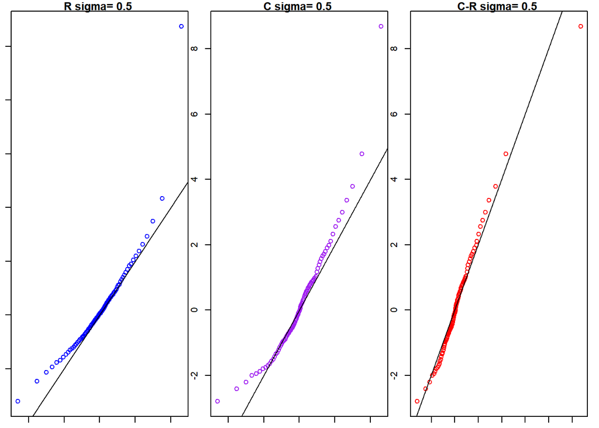

```
##   expr      lq  median       uq
## 1  rwR 60.9582 62.6374 66.79455
## 2  rwC  2.6917  2.7757  2.92070
```

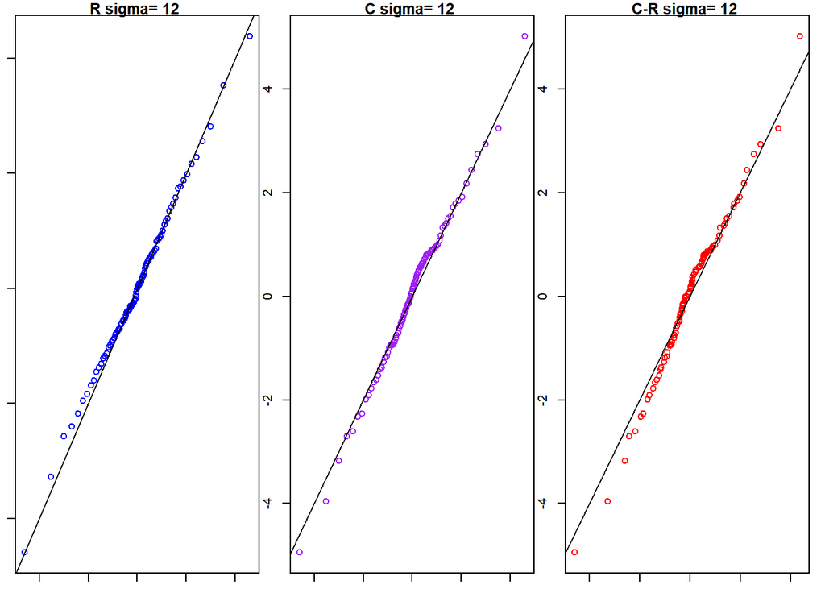

```
##   expr       lq  median       uq
## 1  rwR 60.35085 61.4531 64.75630
## 2  rwC  2.68090  2.7348  2.89205
```

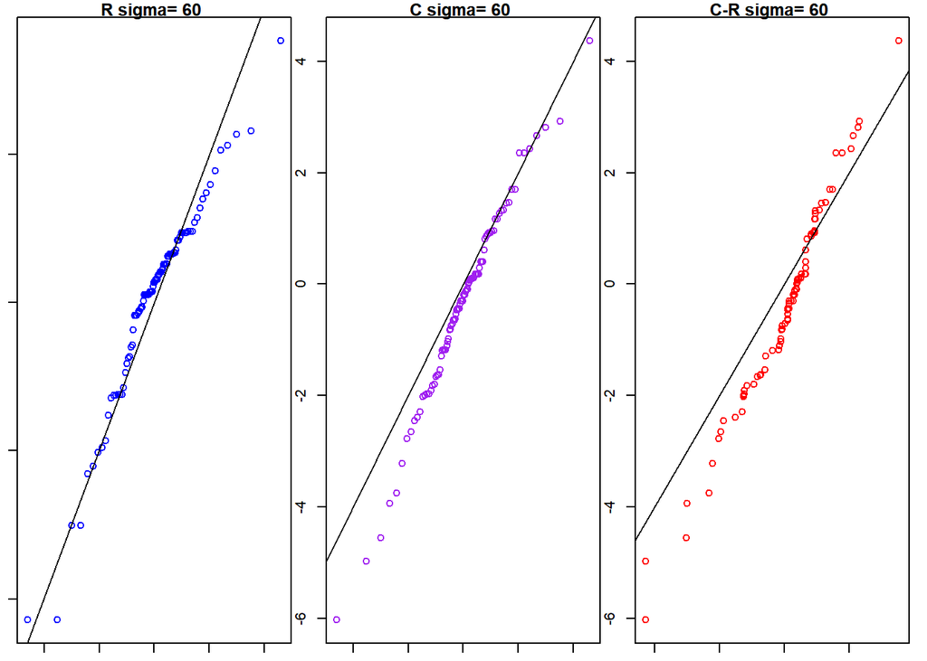

```r
N = 4000
sigma <- c(0.5,12,60)
x0 = 12
for (i in 1:length(sigma)){
ts = microbenchmark(rwR = rw_MetropolisR(sigma[i], x0, N)$x,
                    rwC = rw_MetropolisC(sigma[i], x0, N))
print(summary(ts)[, c(1,3,5,6)])

rwR = rw_MetropolisR(sigma[i], x0, N)$x
rwC = rw_MetropolisC(sigma[i], x0, N)
par(mar=c(1,1,1,1))
par(mfrow = c(1, 3))
b <- 1001 #discard the burnin sample
y <- (rwR)[b:N]
a <- ppoints(100)
QR <- ifelse(a <= 1/2, log(2*a), -log(2-2*a)) #quantiles of Laplace
QQ1 <- quantile(rwR, a)
qqplot(QR, QQ1, main=paste("R sigma=",sigma[i],seq=NULL), xlab="Laplace Quantiles", ylab="Sample Quantiles",col="blue")
abline(a=0, b=1)

y <- (rwC)[b:N]
a <- ppoints(100)
QR <- ifelse(a <= 1/2, log(2*a), -log(2-2*a)) #quantiles of Laplace
QQ2 <- quantile(rwC, a)
qqplot(QR, QQ2, main=paste("C sigma=",sigma[i],seq=NULL), xlab="Laplace Quantiles", ylab="Sample Quantiles",col="purple")
abline(a=0, b=1)

qqplot(QQ1, QQ2, main=paste("C-R sigma=",sigma[i],seq=NULL), xlab="R Samplee Quantiles", ylab="C Sample Quantiles",col="red")
abline(a=0, b=1)
}
```

From the figures above,We will find that Rcpp function’s results are generally the same as R function’s results with different sigmas. However, compared with R function,Rcpp function takes less computational time.